# GroupF_HM2

## FSDS - Chapter 3

### Ex 3.2

*In an exit poll of 1648 voters in the 2020 Senatorial election in Arizona, 51.5% said they voted for Mark Kelly and 48.5% said they voted for Martha McSally.*

*(a) Suppose that actually 50% of the population voted for Kelly. If this exit poll had the properties of a simple random sample, find the standard error of the sample proportion voting for him.*

*(b) Under the 50% presumption, are the results of the exit poll surprising? Why? Would you be willing to predict the election outcome? Explain by (i) conducting a simulation; (ii) using the value found in (a) for the standard error.*

**Solution**

1. Knowing the final result of the election, we can assume the single vote to be a Bernoulli event with $p=0.5$. The corresponding distribution will then have an expectation value of $p$, which will correspond to the proportion of voters for Kelly, and a standard deviation of $p$ as well. Therefor to estimate the proportion of voters for Kelly from a sample of votes (namely the exit poll) we can use the sample mean, which we know to be distributed as a normal distribution with standard deviation $\sigma$/$\sqrt{n}$, where $\sigma$ is the standard deviation of the population and $n$ the size of the samples. So the standard error of the sample proportion is given by:
   $$SE = \frac{p}{\sqrt{1648}} \simeq 0.012.$$
2. We can say that the final result of the election was a little surprising, since (given the result) we had a probability of just 0.21 to get a sample more distant from the real result than the one we got, as we can see from the following chunk:

```r
prob.worse <- 2 * pnorm(0.515, 0.5, 0.012, lower.tail = FALSE)
prob.worse
```

```
## [1] 0.2112995
```

We now simulate 10000 samples of size 1648 under the $50\%$ assumption. We can see that the simulation gives the same results as above:

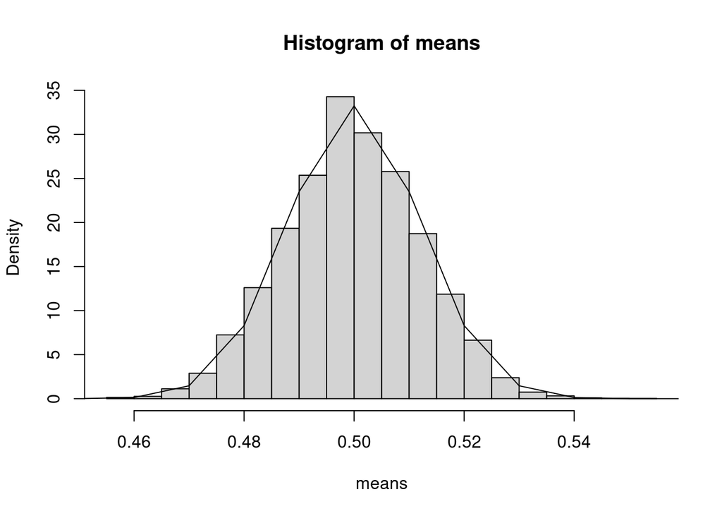

```r
n <- 1648
N <- 10000

samps <- matrix(NA, N, n)
means <- rep(NA, N)
for (i in 1:N) {
  samps[i, ] <- rbinom(n, 1, 0.5)
}
means <- apply(samps, 1, mean)

hist(means, prob = T)
plot(function(x) dnorm(x, 0.5, 0.012), add = T)
```

### Ex 3.16

*According to the U.S. Census Bureau, the number of people in a household has a mean of 2.6 and a standard deviation of 1.5. Suppose the Census Bureau instead had estimated this mean using a random sample of 225 homes, and that sample had a mean of 2.4 and standard deviation of 1.4. Describe the center and spread of the (a) population distribution, (b) sample data distribution, (c) sampling distribution of the sample mean for 225 homes.*

**Solution**

1. The population distribution’s center and spread can be described using respectively the sample mean and the unbiased sample standard deviation (being n = 225): $\bar{x} = 2.4$ and $s = 1.4\sqrt{\frac{n}{n-1}}\simeq1.4$.
2. For the sample we can simply use the the two values 2.4 and 1.4.
3. We can finally describe the center and spread of the sampling distribution for the sample mean using respectively the (already computed) sample mean and the standard error of the mean, which is given by: $\frac{s}{\sqrt{n}}\simeq0.09$.

### Ex 3.24

*Construct a population distribution that is plausible for Y = number of alcoholic drinks in the past day.*

*(a) Simulate a single random sample of size n = 1000 from this population to reflect results of a typical sample survey. Summarize how the sample mean and standard deviation resemble those for the population. (Alternatively, you can do this and part (b) using an app, such as the Sampling Distribution for the Sample Mean (Discrete Population) app at www.artofstat.com/web-apps using the Build Custom Distribution option.)*

*(b) Now draw 10,000 random samples of size 1000 each, to approximate the sampling distribution of Y. Report the mean and standard deviation of this simulated sampling distribution, and compare to the theoretical values. Explain what this sampling distribution represents.*

**Solution**

Since the per capita consumption of alcohol on a daily bases is a rare event (in USA on average ~1 drink), we can assume Y to be distributed according to a Poisson distribution with $\lambda=1$.

```r
lambda <- 1
n <- 1000
samp <- rpois(n, lambda)

m.s <- mean(samp)
sd.s <- sd(samp)

# sample mean
m.s
```

```
## [1] 1.001
```

```r
# sample standard deviation
sd.s
```

```
## [1] 0.9858859
```

The expectation value of the population is $\mu = \lambda = 1$ and the standard deviation $\sigma = \sqrt{\lambda} = 1$, which are near to the values we found.

```r
N <- 10000
n <- 1000

data <- matrix(NA, N, n)
sample.m <- rep(NA, N)
for (i in 1:N) {
  data[i, ] <- rpois(n, lambda)
}
sample.m <- apply(data, 1, mean)

m.m <- mean(sample.m)
sd.m <- sd(sample.m)

# sample mean
m.m
```

```
## [1] 0.9997614
```

```r
# sample standard deviation
sd.m
```

```
## [1] 0.03167227
```

The two parameters estimated in the last chunk are the mean and the standard deviation of the distribution of the sample mean. The theoretical values of the two parameters are respectively: $\mu_\bar{Y} = \mu = \lambda = 1$ , $\sigma_{\bar{Y}} = \frac{\sigma}{\sqrt{n}} = \sqrt{\frac{\lambda}{n}} \simeq 0.03$.

## FSDS - Chapter 4

### Ex 4.8

*To estimate the proportion of traffic deaths in California last year that were alcohol related, determine the necessary sample size for the estimate to be accurate to within 0.04 with probability 0.90. Based on results of studies reported by the National Highway Traffic Safety Administration (www.nhtsa.gov), we expect the proportion to be about 0.30.*

**Solution**

The event ‘related/unrelated to alcohol’ is a Bernoulli experiment with probability $p$ (probability for the death to be related to alcohol). Then the true proportion of deaths for alcohol is equal to the expectation value $p$ of the Bernoulli distribution. Therefor, given a sample, we can estimate the proportion using the sample mean. We know that the expected proportion (namely the expectation value of the Bernoulli distribution $\mu$) is $p=0.30$, and that the sample mean is distributed normally with mean equal to the expected value of the population and standard deviation equal to $\sigma$/$\sqrt{n}$ (with $\sigma$ standard deviation of the population and $n$ size of the samples). To have a probability of $90\%$ for a single estimate to be within a distance of $0.04$ from the true value of the proportion, we have to take $n$ such that the probability computed between $p-0.04$ and $p+0.04$ is $0.9$. Calling $\bar{x}$ the sample proportion, and remembering that $\sigma=p$ and $\mu=p$, we have:
$$P\left(Q_{05}<\frac{\bar{x}-p}{\frac{\sqrt{p\left(1-p\right)}}{\sqrt{n}}}<Q_{95}\right)
= 0.9,$$
where $Q_{05}$ and $Q_{95}$ are the two percentiles of order 5 and 95 of the standard normal distribution. Since we want $\hat{x}$ to be within $\left(0.26, 0.34\right)$, we get the two equations:
$$p + \frac{p}{\sqrt{n}}Q_{05} = 0.26$$
$$p + \frac{p}{\sqrt{n}}Q_{95} = 0.34$$
We finally compute n, using one of the two equations:

```r
# sbagliata la deviazione standard

p <- 0.3

# computing the quantiles for a standard normal distribution
Q05 <- qnorm(0.05)

n <- p^2 * Q05^2 / (0.26 - p)^2
n
```

```
## [1] 152.1868
```

### Ex 4.14

*Using the Students data file, for the corresponding population, construct a 95% confidence interval (a) for the mean weekly number of hours spent watching TV; (b) to compare females and males on the mean weekly number of hours spent watching TV. In each case, state assumptions, including the practical importance of each, and interpret results.*

**Solution**

1. Assuming independent variables:

```r
# getting the data
setwd(getwd())
data <- read.table("Students.dat", header = T)

tv <- data$tv
n <- length(tv)
m <- mean(tv)
s <- sd(tv)

# sample mean
mean(tv)
```

```
## [1] 7.266667
```

We can then find the confidence interval (with $\alpha=0.05$) as:
$$\left[\bar{y}-t_{n-1}^{0.025}\frac{s}{\sqrt{n}},\bar{y}+t_{n-1}^{0.025}\frac{s}{\sqrt{n}}\right],$$
where $\bar{y}$ and $s$ are the sample mean and standard deviation, n is the sample size and the $t_{n-1}$’s are the quantiles of the student t distribution with n-1 degrees of freedom.

```r
# computing the boundaries of the interval
Q025 <- m + (s/sqrt(n)) * qt(0.025, n-1)
Q975 <- m + (s/sqrt(n)) * qt(0.975, n-1)

Q025; Q975
```

```
## [1] 5.531395
```

```
## [1] 9.001938
```

2. We assume $0=male$ and $1=female$ in the dataset. We are dealing with the difference between two means, so the confidence interval can be expressed by:
   $$\left[\bar{y_0}-\bar{y_1}-t_{n_0+n_1-2}^{0.025}\cdot se,
   \bar{y_0}-\bar{y_1}+t_{n_0+n_1-2}^{0.025}\cdot se\right],$$
   where
   $$se = s\cdot\sqrt{\frac{1}{n_0}+\frac{1}{n_1}} =
   \sqrt{\frac{\left(n_0-1\right)s_0^2\left(n_1-1\right)s_1^2}{\left(n_0-1\right)+\left(n_1-1\right)}}
   \cdot\sqrt{\frac{1}{n_0}+\frac{1}{n_1}}$$

```r
males <- data$tv[data$gender == 0]
females <- data$tv[data$gender == 1]
n0 <- length(males)
n1 <- length(females)

# computing parameters for the difference
mD <- mean(males) - mean(females)
s0 <- sd(males)
s1 <- sd(females)
se <- sqrt((var(males)*(n0 - 1) + var(females)*(n1 - 1))/(n0 + n1 - 2)) * sqrt(1/n0 + 1/n1)

# computing the boundaries of the interval
Q025 <- mD + se * qt(0.025, n0+n1-2)
Q975 <- mD + se * qt(0.975, n0+n1-2)

Q025; Q975
```

```
## [1] -4.965639
```

```
## [1] 1.997897
```

### Ex 4.34

*Using simulation, conduct an investigation of whether the sample mean or median is a better estimator of the common value for the mean and median of a uniform distribution.*

**Solution**

To understand which of the two is the better estimator we can compute the mean squared error for both:

```r
N <- 10000
n <- 1000

m.true <- 5
sd.true <- 2

data <- matrix(NA, N, n)
means <- rep(NA, N)
medians <- rep(NA, N)
for (i in 1:N) {
  data[i, ] <- rnorm(n, m.true, sd.true)
}
means <- apply(data, 1, mean)
medians <- apply(data, 1, median)

MSE.mean <- mean((means-m.true)^2)
MSE.median <- mean((medians-m.true)^2)

MSE.mean
```

```
## [1] 0.003936781
```

```r
MSE.median
```

```
## [1] 0.006155318
```

### Ex 4.48

*For a simple random sample of n subjects, explain why it is about 95% likely that the sample proportion has error no more than 1/$\sqrt{n}$ in estimating the population proportion. (Hint: To show this “1/$\sqrt{n}$ rule,” find two standard errors when $\pi$ = 0.50, and explain how this compares to two standard errors at other values of $\pi$.) Using this result, show that $n$ = 1/$M^2$ is a safe sample size for estimating a proportion to within M with 95% confidence.*

**Solution**

We start by considering the function $f\left(\pi\right)=\sqrt{\pi(1-\pi)}$, with $0<\pi<1$, that associates to each Bernoulli distribution (identified by the probability $\pi$) the corresponding standard deviation. Studying the derivatives of the function it is easy to show that it is maximized by $\pi=0.5$. Given a Bernoulli distribution, the proportion can be estimated by the sample mean, which is distributed normally with a standard deviation of $\sigma$/$\sqrt{n}=\sqrt{\pi\left(\pi-1\right)}$/$\sqrt{n}$ around the expectation value of the Bernoulli distribution $\pi$. So, remembering that in a normal distribution about $95\%$ of the probability lies within 2 standard deviations from the mean, we have that with a probability of $95\%$ an extracted sample will produce an estimate of the proportion that is less than $2\sqrt{\pi\left(\pi-1\right)}$/$\sqrt{n}$ far from the true value; because of what we said about $f$, this last quantity is always smaller or equal to $1$/$\sqrt{n}$.

If we use a sample of size $n=1$/$M^2$, using what we just found, we get that the proportion will fall within a distance of $M$ from the true value with a probability of $95\%$.

### Ex 4.54

*Consider n independent observations from an exponential pdf f(y; $\lambda$) = $\lambda$e-$\lambda$y for y $\ge$ 0, with parameter $\lambda > 0$ for which E(Y) = 1/$\lambda$.*

*(a) Find the sufficient statistic for estimating $\lambda$.*

*(b) Find the maximum likelihood estimator of $\lambda$ and of E(Y).*

*(c) One can show that 2$\lambda\left(\sum_i{Y_i}\right)$ has a chi-squared distribution with df = 2n. Explain why 2$\lambda\left(\sum_i{Y_i}\right)$ is a pivotal quantity, and use it to derive a 95% confidence interval for $\lambda$.*

**Solution**

1. We can prove that $\sum_{i=0}^n{y_i}$ is a sufficient statistic for $\lambda$, infact we can write the joint probability of getting the sample $\{y_i\}$ as:
   $$f(\{y_i\}_i; \lambda) = \lambda^n\exp(-\lambda\sum{y_i}),$$
   which is in the form $f(\{y_i\}_i; \lambda) = h(\{y_i\}_i)g_\lambda\left[t(\{y_i\}_i)\right]$.
2. The maximum likelihood estimator is the one that maximizes the log-likelihood function. In the case of $\lambda$ we can write the log likelihood function as:
   $$l\left(\lambda\right) = \sum_i{\log{e^{-\lambda y_i}}} =
   n\log(\lambda)-\lambda\sum_iy_i,$$
   which is minimized for:
   $$\hat{\lambda}_{ML} = \frac{n}{\sum_iy_i}.$$
   Called M the expectation value of Y, we can write the log-likelihood as:
   $$l\left(M\right) = \sum_i{\log{e^{-\frac{1}{M} y_i}}} =
   n\log(\frac{1}{M})-\frac{1}{M}\sum_iy_i,$$
   which is minimized for:
   $$\hat{M}_{ML} = \frac{\sum_i{y_i}}{n}.$$
3. It is a pivotal quantity because it is a function of the parameter we want to estimate and the sample whose distribution is known. Since the known distribution of the pivotal quantity is a chi-squared with $df=2n$, we have:
   $$P\left(Q_{025}^{\chi^2_{2n}} < 2\lambda\sum_i{y_i} <
   Q_{975}^{\chi^2_{2n}}\right) = 0.95,$$
   where $Q_k^{\chi^2}$ are the 0.025 and 0.975 quantiles of the chi-squared distribution. As a result we get the confidence interval for $\lambda$:
   $$\left(\frac{Q_{025}^{\chi^2_{2n}}}{2\sum{y_i}},\frac{Q_{975}^{\chi^2_{2n}}}{2\sum{y_i}}\right).$$

## FSDS - Chapter 5

### Ex 5.8

*For the Students data file at the text website, analyze political ideology.*

*(a) Test whether the population mean $\mu$ differs from 4.0, the moderate response. Report the P-value, and interpret. Make a conclusion using $\alpha$-level = 0.05.*

*(b) Construct the 95% confidence interval for $\mu$. Explain how results relate to those of the test in (a).*

**Solution**

1. We can use the pivotal quantity:
   $$T = \frac{\bar{x}-\mu}{\frac{s}{\sqrt{n}}},$$
   which is distributed according to a student t distribution with $n-1$ degrees of freedom.

```r
# getting data
setwd(getwd())
data <- read.table("Students.dat", header = T)
pol <- data$ideol

# parameters
n <- length(pol)
mu0 <- 4
alpha <- 0.05

# computing p-value
t <- (mean(pol)-mu0) / (sd(pol)/sqrt(n))
if (t > 0) {
  p.val <- pt(t, n-1, lower.tail = F) * 2
} else {
  p.val <- pt(t, n-1) * 2
}

p.val
```

```
## [1] 2.48372e-05
```

The result strongly suggests to reject the null hypothesis $\mu=4$.

2. We can use the same pivotal quantity to compute the boundaries of the interval

```r
n <- length(pol)

Q <- qt(0.975, n-1) * sd(pol) / sqrt(n)
C.left <- mean(pol) - Q
C.right <- mean(pol) + Q

C.left; C.right
```

```
## [1] 2.610683
```

```
## [1] 3.455984
```

The result seems to be coherent with the one found in (a), since the value of 4 is clearly out of the confidence interval.

### Ex 5.16

*An experiment used a sample of college students to investigate whether cell phone use impairs drivers’ reaction times. On a machine that simulated driving situations, at irregular periods a target flashed red or green. Participants were instructed to press a brake button as soon as possible when they detected a red light. Under the cell phone condition, each student carried out a conversation on a cell phone with someone in a separate room. In the control condition, the same students listened to a radio broadcast. The CellPhone data file records the students’ mean response times (in milliseconds) over several trials for each condition, $\{y_{i1}\}$ for the cell phone condition and $\{y_{i2}\}$ for control.*

*(a) The comparisons of means or proportions in this chapter assume independent samples for the two groups. Explain why the samples for these two conditions are dependent rather than independent.*

*(b) To compare $\mu_1$ and $\mu_2$, you can use $\{d_i = y_{i1} - y_{i2}, i = 1, . . . , n\}$, here with n = 8. Specify the parameter $\mu_d$ and $H_0$ for doing this, and explain why $\mu_d = \mu_1 - \mu_2$.*

*(c) State the assumptions and test statistic, explain why it has a t distribution with df = n-1. Report the P-value with two-sided $H_a$, and interpret. (The test is called a matched-pairs t test. Matched-pairs analyses also are possible with confidence intervals, as Section 4.4.3 did in comparing weights of anorexic girls before and after a period of treatment by analyzing the mean difference in weights.)*

**Solution**

1. The variables inside the same group can be considered to be independent, but there is a dependency between the same students’ reaction time in cell phone condition and in radio condition. That is because the personal reaction time has to be taken into account. For example we could have a reaction time in a given condition resulting from product of fixed coefficient (the same for everybody) and a personal time of reaction, formally:
   $$T_{cellphone,i} = CT_i,$$
   $$T_{radio,i} = RT_i,$$
   from which we get:
   $$T_{radio,i} = \frac{R}{C}T_{cellphone,i},$$
   that gives the dependency among the two variables.

```r
setwd(getwd())
data <- read.table("CellPhone.dat", header = TRUE)
```

### Ex 5.58

*A researcher conducts a significance test every time she analyzes a new data set. Over time, she conducts 100 significance tests, each at the 0.05 level. If $H_0$ is true in every case, what is the probability distribution of the number of times she rejects $H_0$, and how many times would we expect $H_0$ to be rejected?*

**Solution**

Whatever the test statistic t the researcher will choose, since we know that $H_0$ is true, the distribution she will draw for t will be the true one. So, extracting a random sample, t will have a probability of 0.05 of falling in the rejection region. We can then consider the rejection/acceptance of $H_0$ as a Bernoulli experiment with $p=0.05$ (probability for $H_0$ to be rejected), and so, given the number $n$ of samples on which she performs the evaluation, we can build the distribution of the number of rejections as the binomial with $p=0.05$:
$$f\left(x\right) = \binom{n}{x}p^x\left(1-p\right)^{n-x}.$$
Therefor we expect on average to have $np$ rejections of $H_0$ (i.e. the $5\%$ of the times).

### Ex 5.68

*Explain why the confidence interval based on the Wald test of $H_0$: $\theta=\theta_0$ is symmetric around $\hat{\theta}$ (i.e., having center exactly equal to $\hat{\theta}$. This is not true for the confidence intervals based on the likelihood-ratio and score tests.) Explain why such symmetry can be problematic when $\theta$ and $\hat{\theta}$ are near a boundary, using the example of a population proportion that is very close to 0 or 1 and a sample proportion that may well equal 0 or 1.*

**Solution**